# Stout_Case_Study

Jiade Song ; r8072022_Analyst_Digital_Data_Analytics

```python
import pandas as pd
import numpy as np
import matplotlib.pyplot as plt
import seaborn as sns
from sklearn.impute import KNNImputer
from sklearn.preprocessing import LabelEncoder
from sklearn.preprocessing import StandardScaler
from sklearn.model_selection import train_test_split
from sklearn.svm import LinearSVC
from sklearn.metrics import accuracy_score
from sklearn.linear_model import LogisticRegression
from sklearn import svm
```

Case Study #1

### Below is a data set that represents thousands of loans made through the Lending Club platform, which is a platform that allows individuals to lend to other individuals.

### We would like you to perform the following using the language of your choice:

```python
file_path1 = r'loans_full_schema.csv'
dataset1 = pd.read_csv(file_path1, delimiter=",")
```

```python
dataset1
```

|  | emp_title | emp_length | state | homeownership | annual_income | verified_income | debt_to_income | annual_income_joint | verification_income_joint | debt_to_income_joint | ... | sub_grade | issue_month | loan_status | initial_listing_status | disbursement_method | balance | paid_total | paid_principal | paid_interest | paid_late_fees |
| --- | --- | --- | --- | --- | --- | --- | --- | --- | --- | --- | --- | --- | --- | --- | --- | --- | --- | --- | --- | --- | --- |
| 0 | global config engineer | 3.0 | NJ | MORTGAGE | 90000.0 | Verified | 18.01 | NaN | NaN | NaN | ... | C3 | Mar-2018 | Current | whole | Cash | 27015.86 | 1999.33 | 984.14 | 1015.19 | 0.0 |
| 1 | warehouse office clerk | 10.0 | HI | RENT | 40000.0 | Not Verified | 5.04 | NaN | NaN | NaN | ... | C1 | Feb-2018 | Current | whole | Cash | 4651.37 | 499.12 | 348.63 | 150.49 | 0.0 |
| 2 | assembly | 3.0 | WI | RENT | 40000.0 | Source Verified | 21.15 | NaN | NaN | NaN | ... | D1 | Feb-2018 | Current | fractional | Cash | 1824.63 | 281.80 | 175.37 | 106.43 | 0.0 |
| 3 | customer service | 1.0 | PA | RENT | 30000.0 | Not Verified | 10.16 | NaN | NaN | NaN | ... | A3 | Jan-2018 | Current | whole | Cash | 18853.26 | 3312.89 | 2746.74 | 566.15 | 0.0 |
| 4 | security supervisor | 10.0 | CA | RENT | 35000.0 | Verified | 57.96 | 57000.0 | Verified | 37.66 | ... | C3 | Mar-2018 | Current | whole | Cash | 21430.15 | 2324.65 | 1569.85 | 754.80 | 0.0 |
| ... | ... | ... | ... | ... | ... | ... | ... | ... | ... | ... | ... | ... | ... | ... | ... | ... | ... | ... | ... | ... | ... |
| 9995 | owner | 10.0 | TX | RENT | 108000.0 | Source Verified | 22.28 | NaN | NaN | NaN | ... | A4 | Jan-2018 | Current | whole | Cash | 21586.34 | 2969.80 | 2413.66 | 556.14 | 0.0 |
| 9996 | director | 8.0 | PA | MORTGAGE | 121000.0 | Verified | 32.38 | NaN | NaN | NaN | ... | D3 | Feb-2018 | Current | whole | Cash | 9147.44 | 1456.31 | 852.56 | 603.75 | 0.0 |
| 9997 | toolmaker | 10.0 | CT | MORTGAGE | 67000.0 | Verified | 45.26 | 107000.0 | Source Verified | 29.57 | ... | E2 | Feb-2018 | Current | fractional | Cash | 27617.65 | 4620.80 | 2382.35 | 2238.45 | 0.0 |
| 9998 | manager | 1.0 | WI | MORTGAGE | 80000.0 | Source Verified | 11.99 | NaN | NaN | NaN | ... | A1 | Feb-2018 | Current | whole | Cash | 21518.12 | 2873.31 | 2481.88 | 391.43 | 0.0 |
| 9999 | operations analyst | 3.0 | CT | RENT | 66000.0 | Not Verified | 20.82 | NaN | NaN | NaN | ... | B4 | Feb-2018 | Current | whole | Cash | 11574.83 | 1658.56 | 1225.17 | 433.39 | 0.0 |

10000 rows × 55 columns

#### • Describe the dataset and any issues with it.

###### This dataset includes the infomation of loans and the borrowers. There are 10000 observations and 55 variables. Some of the columns are numerical and others are categorical. In the following columns, there are at least one NaN. All the loans are issued in 2018.

```python
dataset1.loc[:, dataset1.isna().any()]
```

|  | emp_title | emp_length | debt_to_income | annual_income_joint | verification_income_joint | debt_to_income_joint | months_since_last_delinq | months_since_90d_late | months_since_last_credit_inquiry | num_accounts_120d_past_due |
| --- | --- | --- | --- | --- | --- | --- | --- | --- | --- | --- |
| 0 | global config engineer | 3.0 | 18.01 | NaN | NaN | NaN | 38.0 | 38.0 | 5.0 | 0.0 |
| 1 | warehouse office clerk | 10.0 | 5.04 | NaN | NaN | NaN | NaN | NaN | 8.0 | 0.0 |
| 2 | assembly | 3.0 | 21.15 | NaN | NaN | NaN | 28.0 | 28.0 | 7.0 | 0.0 |
| 3 | customer service | 1.0 | 10.16 | NaN | NaN | NaN | NaN | NaN | 15.0 | 0.0 |
| 4 | security supervisor | 10.0 | 57.96 | 57000.0 | Verified | 37.66 | NaN | NaN | 4.0 | 0.0 |
| ... | ... | ... | ... | ... | ... | ... | ... | ... | ... | ... |
| 9995 | owner | 10.0 | 22.28 | NaN | NaN | NaN | NaN | NaN | 6.0 | 0.0 |
| 9996 | director | 8.0 | 32.38 | NaN | NaN | NaN | 9.0 | 9.0 | 1.0 | 0.0 |
| 9997 | toolmaker | 10.0 | 45.26 | 107000.0 | Source Verified | 29.57 | 6.0 | NaN | 16.0 | 0.0 |
| 9998 | manager | 1.0 | 11.99 | NaN | NaN | NaN | NaN | NaN | 5.0 | 0.0 |
| 9999 | operations analyst | 3.0 | 20.82 | NaN | NaN | NaN | NaN | NaN | 18.0 | 0.0 |

10000 rows × 10 columns

#### • Generate a minimum of 5 unique visualizations using the data and write a brief description of your observations. Additionally, all attempts should be made to make the visualizations visually appealing

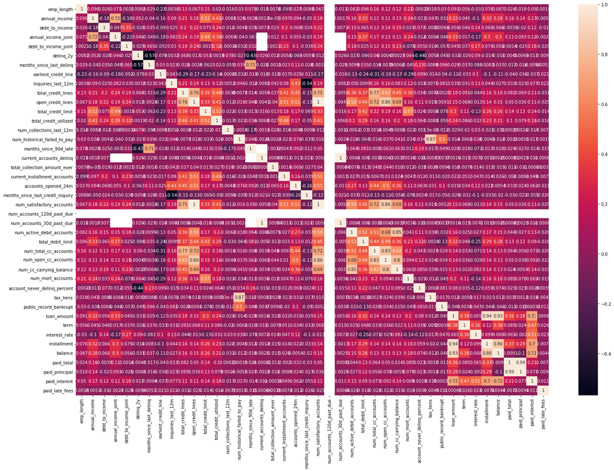

```python
plt.figure(figsize=(25, 17))
sns.heatmap(dataset1.corr(), annot=True)
```

Graph 1.1.1

[output not shown]

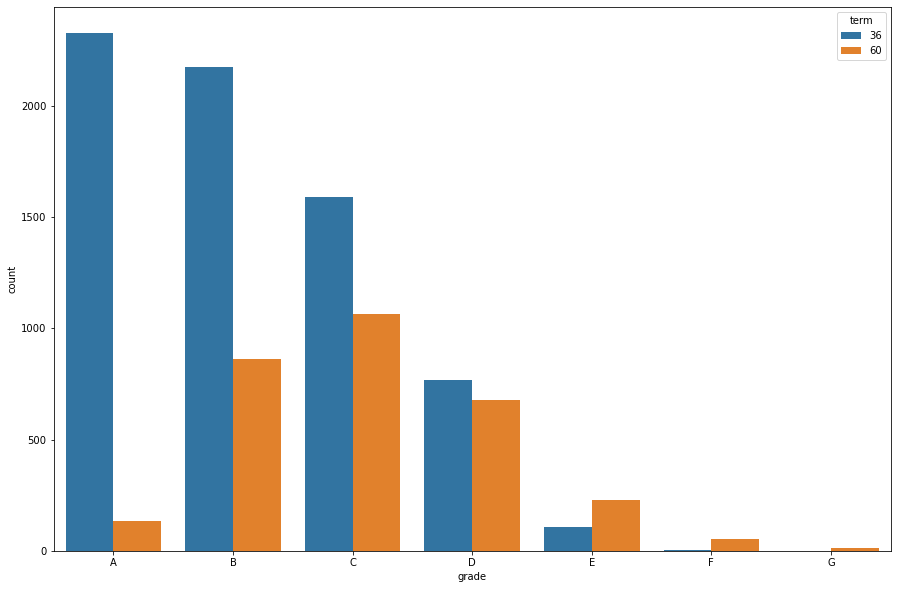

```python
plt.figure(figsize=(15, 10))
grade = sorted(dataset1.grade.unique().tolist())
sns.countplot(x='grade', data=dataset1, hue='term', order=grade)
```

Graph 1.1.2

```
Graph 1.1.2
A shorter term of the loan tends to have a better grade (A or B).
In other words, most 60-month loans are in grade B and C, however, most 36-month loans are in grade A and B.
```

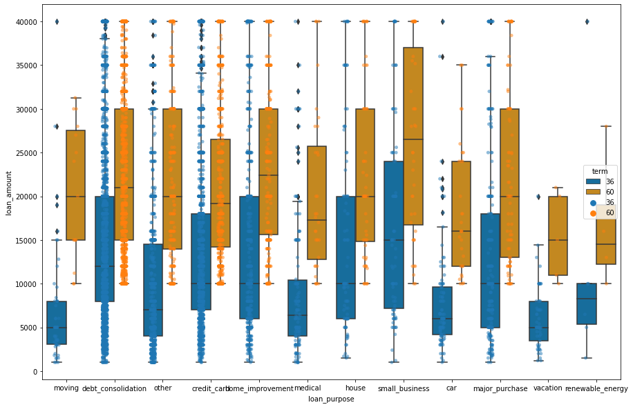

```python
plt.figure(figsize=(15, 10))
sns.boxplot(y='loan_amount', x='loan_purpose', data=dataset1, palette="colorblind", hue='term')
sns.stripplot(y='loan_amount', x='loan_purpose', data=dataset1, dodge=True,  jitter=True, marker='o', alpha=0.5,hue='term')
```

Graph 1.1.3

```
Graph 1.1.3
1. For all different categories of loan purposes, the 60-month loans tend to have a larger loan amount values.
2. The largest loan amount category is small business.
```

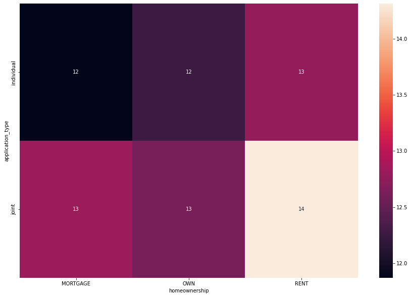

```python
plt.figure(figsize=(15, 10))
df_heatmap = dataset1.pivot_table(values='interest_rate',index='application_type',columns='homeownership',aggfunc=np.mean)
sns.heatmap(df_heatmap,annot=True)
plt.show()
```

Graph 1.1.4

```
Graph 1.1.4
Individual applicants with mortgage have a smaller interest rates but joint applicants with rent houses are having larger interest rates.
```

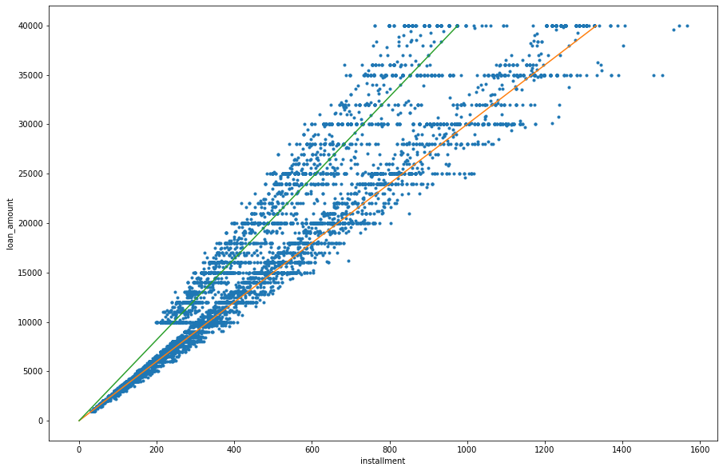

```python
plt.figure(figsize=(15, 10))
a_list = list(range(1,40000))
b = [x / 30 for x in a_list]
c = [x / 41 for x in a_list]
plt.plot(dataset1['installment'],dataset1['loan_amount'],'.')
plt.plot(b,a_list,'-')
plt.plot(c,a_list,'-')
plt.xlabel('installment')
plt.ylabel('loan_amount')
```

Graph 1.1.5

```
Graph 1.1.5
The plot of loan amount vs installment could be fitted by two lines which are for 36 months and 60 month. The green and yellow lines above are the approximate fitted lines.
```

#### • Create a feature set and create a model which predicts interest_rate using at least 2 algorithms. Describe any data cleansing that must be performed and analysis when examining the data.

```python
cols =['emp_length','annual_income','homeownership','total_credit_limit','total_debit_limit','num_open_cc_accounts',\
        'num_mort_accounts','application_type','loan_amount','term']
df_x = dataset1[cols]
df_y = dataset1['sub_grade']
df_x

# 10 variables are selected. two are categorical.
```

|  | emp_length | annual_income | homeownership | total_credit_limit | total_debit_limit | num_open_cc_accounts | num_mort_accounts | application_type | loan_amount | term |
| --- | --- | --- | --- | --- | --- | --- | --- | --- | --- | --- |
| 0 | 3.0 | 90000.0 | MORTGAGE | 70795 | 11100 | 8 | 1 | individual | 28000 | 60 |
| 1 | 10.0 | 40000.0 | RENT | 28800 | 16500 | 14 | 0 | individual | 5000 | 36 |
| 2 | 3.0 | 40000.0 | RENT | 24193 | 4300 | 8 | 0 | individual | 2000 | 36 |
| 3 | 1.0 | 30000.0 | RENT | 25400 | 19400 | 3 | 0 | individual | 21600 | 36 |
| 4 | 10.0 | 35000.0 | RENT | 69839 | 32700 | 15 | 0 | joint | 23000 | 36 |
| ... | ... | ... | ... | ... | ... | ... | ... | ... | ... | ... |
| 9995 | 10.0 | 108000.0 | RENT | 199195 | 44600 | 9 | 1 | individual | 24000 | 36 |
| 9996 | 8.0 | 121000.0 | MORTGAGE | 382061 | 28200 | 11 | 2 | individual | 10000 | 36 |
| 9997 | 10.0 | 67000.0 | MORTGAGE | 346402 | 14900 | 7 | 2 | joint | 30000 | 36 |
| 9998 | 1.0 | 80000.0 | MORTGAGE | 294475 | 46000 | 9 | 6 | individual | 24000 | 36 |
| 9999 | 3.0 | 66000.0 | RENT | 91887 | 36800 | 5 | 0 | individual | 12800 | 36 |

10000 rows × 10 columns

```python
label_encoder = LabelEncoder()
df_x['homeownership'] = label_encoder.fit_transform(df_x['homeownership'])
df_x['application_type'] = label_encoder.fit_transform(df_x['application_type'])
df_x
```

|  | emp_length | annual_income | homeownership | total_credit_limit | total_debit_limit | num_open_cc_accounts | num_mort_accounts | application_type | loan_amount | term |
| --- | --- | --- | --- | --- | --- | --- | --- | --- | --- | --- |
| 0 | 3.0 | 90000.0 | 0 | 70795 | 11100 | 8 | 1 | 0 | 28000 | 60 |
| 1 | 10.0 | 40000.0 | 2 | 28800 | 16500 | 14 | 0 | 0 | 5000 | 36 |
| 2 | 3.0 | 40000.0 | 2 | 24193 | 4300 | 8 | 0 | 0 | 2000 | 36 |
| 3 | 1.0 | 30000.0 | 2 | 25400 | 19400 | 3 | 0 | 0 | 21600 | 36 |
| 4 | 10.0 | 35000.0 | 2 | 69839 | 32700 | 15 | 0 | 1 | 23000 | 36 |
| ... | ... | ... | ... | ... | ... | ... | ... | ... | ... | ... |
| 9995 | 10.0 | 108000.0 | 2 | 199195 | 44600 | 9 | 1 | 0 | 24000 | 36 |
| 9996 | 8.0 | 121000.0 | 0 | 382061 | 28200 | 11 | 2 | 0 | 10000 | 36 |
| 9997 | 10.0 | 67000.0 | 0 | 346402 | 14900 | 7 | 2 | 1 | 30000 | 36 |
| 9998 | 1.0 | 80000.0 | 0 | 294475 | 46000 | 9 | 6 | 0 | 24000 | 36 |
| 9999 | 3.0 | 66000.0 | 2 | 91887 | 36800 | 5 | 0 | 0 | 12800 | 36 |

10000 rows × 10 columns

```python
imputer = KNNImputer(n_neighbors=4)

df_x_imputed = pd.DataFrame(imputer.fit_transform(df_x),columns = df_x.columns)
df_x_imputed
```

|  | emp_length | annual_income | homeownership | total_credit_limit | total_debit_limit | num_open_cc_accounts | num_mort_accounts | application_type | loan_amount | term |
| --- | --- | --- | --- | --- | --- | --- | --- | --- | --- | --- |
| 0 | 3.0 | 90000.0 | 0.0 | 70795.0 | 11100.0 | 8.0 | 1.0 | 0.0 | 28000.0 | 60.0 |
| 1 | 10.0 | 40000.0 | 2.0 | 28800.0 | 16500.0 | 14.0 | 0.0 | 0.0 | 5000.0 | 36.0 |
| 2 | 3.0 | 40000.0 | 2.0 | 24193.0 | 4300.0 | 8.0 | 0.0 | 0.0 | 2000.0 | 36.0 |
| 3 | 1.0 | 30000.0 | 2.0 | 25400.0 | 19400.0 | 3.0 | 0.0 | 0.0 | 21600.0 | 36.0 |
| 4 | 10.0 | 35000.0 | 2.0 | 69839.0 | 32700.0 | 15.0 | 0.0 | 1.0 | 23000.0 | 36.0 |
| ... | ... | ... | ... | ... | ... | ... | ... | ... | ... | ... |
| 9995 | 10.0 | 108000.0 | 2.0 | 199195.0 | 44600.0 | 9.0 | 1.0 | 0.0 | 24000.0 | 36.0 |
| 9996 | 8.0 | 121000.0 | 0.0 | 382061.0 | 28200.0 | 11.0 | 2.0 | 0.0 | 10000.0 | 36.0 |
| 9997 | 10.0 | 67000.0 | 0.0 | 346402.0 | 14900.0 | 7.0 | 2.0 | 1.0 | 30000.0 | 36.0 |
| 9998 | 1.0 | 80000.0 | 0.0 | 294475.0 | 46000.0 | 9.0 | 6.0 | 0.0 | 24000.0 | 36.0 |
| 9999 | 3.0 | 66000.0 | 2.0 | 91887.0 | 36800.0 | 5.0 | 0.0 | 0.0 | 12800.0 | 36.0 |

10000 rows × 10 columns

```python
X_train, X_test, y_train, y_test = train_test_split(df_x_imputed, df_y,test_size=0.2, random_state=24)
```

```python
scaler = StandardScaler()
X_train_norm = scaler.fit_transform(X_train)
X_test_norm = scaler.transform(X_test)
X_train_norm_df = pd.DataFrame(X_train_norm, columns=X_train.columns)
X_test_norm_df = pd.DataFrame(X_test_norm, columns=X_test.columns)
X_train_norm_df
```

|  | emp_length | annual_income | homeownership | total_credit_limit | total_debit_limit | num_open_cc_accounts | num_mort_accounts | application_type | loan_amount | term |
| --- | --- | --- | --- | --- | --- | --- | --- | --- | --- | --- |
| 0 | 0.173063 | 0.463165 | 0.100198 | 0.498328 | 5.024642 | 5.084074 | 0.359044 | -0.419466 | 0.735156 | 1.508198 |
| 1 | -0.243100 | -0.313242 | -0.981565 | -0.357334 | -0.500471 | -0.427477 | 0.940844 | 2.383983 | 0.502429 | 1.508198 |
| 2 | 1.144112 | -0.733796 | 1.181962 | -0.796193 | -0.721623 | -0.427477 | -0.804557 | -0.419466 | 0.778793 | 1.508198 |
| 3 | -1.075428 | 0.657267 | 1.181962 | -0.796015 | -0.950147 | -1.039871 | -0.804557 | -0.419466 | 1.801826 | -0.663043 |
| 4 | -1.352870 | 0.010261 | 1.181962 | -0.687490 | -0.537330 | -0.835740 | -0.804557 | -0.419466 | -0.777575 | -0.663043 |
| ... | ... | ... | ... | ... | ... | ... | ... | ... | ... | ... |
| 7995 | 0.311785 | -0.361768 | -0.981565 | -0.646733 | -0.839571 | -0.631608 | 0.359044 | -0.419466 | -1.049091 | -0.663043 |
| 7996 | -0.243100 | 0.867544 | -0.981565 | 2.289214 | 0.240388 | 1.409707 | 1.522644 | -0.419466 | 0.832126 | 1.508198 |
| 7997 | 1.144112 | 0.252888 | -0.981565 | 0.772344 | -0.076596 | 0.389049 | 3.849846 | -0.419466 | 2.286676 | -0.663043 |
| 7998 | -1.075428 | -0.652920 | 0.100198 | -0.886798 | -0.330921 | -0.835740 | -0.804557 | -0.419466 | 1.316976 | 1.508198 |
| 7999 | -0.520543 | -0.555853 | 0.100198 | -0.906242 | -1.016492 | -1.244003 | -0.804557 | -0.419466 | 0.153337 | -0.663043 |

8000 rows × 10 columns

```python
y_train
```

```
6604    B1
3203    C3
2195    D2
2576    C3
4572    B1
        ..
6500    B5
5249    C1
3473    A5
8535    D5
899     D4
Name: sub_grade, Length: 8000, dtype: object
```

```python
clf = LinearSVC(penalty='l1',loss='squared_hinge',dual=False ,random_state=24,max_iter=100000).fit(X_train, y_train)
```

```python
pred_svc_test = clf.predict(X_test)
test_acc = accuracy_score(y_test,pred_svc_test)
test_acc
```

```
0.093
```

```python
poly = svm.SVC(kernel='poly', degree=3, C=1).fit(X_train, y_train)
```

```python
poly_pred = poly.predict(X_test)
test_acc = accuracy_score(y_test,poly_pred)
test_acc
```

```
0.067
```

#### • Visualize the test results and propose enhancements to the model, what would you do if you had more time. Also describe assumptions you made and your approach.

The LinearSVC and poly-svc model I tried had a pretty poor behavior in classifying the the grades accurately. Because there are so many classes, the boundries are hard to detect.

1. If more time given, I would try to use regression models to predict the interest rate values directly and assigning it to the closest interest rate level (corresponding sub_grade).
2. Another method that i think would work is to perform CNN with more variables in a Multi-Layer Perceptron model. This method takes more time but could find more hidden principles.

Case Study #2

```python
file_path2 = r'casestudy.csv'
dataset2 = pd.read_csv(file_path2 , delimiter=",")
```

```python
dataset2
```

|  | Unnamed: 0 | customer_email | net_revenue | year |
| --- | --- | --- | --- | --- |
| 0 | 0 | nhknapwsbx@gmail.com | 249.92 | 2015 |
| 1 | 1 | joiuzbvcpn@gmail.com | 87.61 | 2015 |
| 2 | 2 | ukkjctepxt@gmail.com | 168.38 | 2015 |
| 3 | 3 | gykatilzrt@gmail.com | 62.40 | 2015 |
| 4 | 4 | mmsgsrtxah@gmail.com | 43.08 | 2015 |
| ... | ... | ... | ... | ... |
| 685922 | 685922 | qzqttwiftu@gmail.com | 184.58 | 2017 |
| 685923 | 685923 | pjodiifjop@gmail.com | 133.03 | 2017 |
| 685924 | 685924 | appaplmgko@gmail.com | 200.98 | 2017 |
| 685925 | 685925 | wvkpmwsgck@gmail.com | 235.35 | 2017 |
| 685926 | 685926 | aregboumbw@gmail.com | 208.43 | 2017 |

685927 rows × 4 columns

#### • Total revenue for the current year

```python
dataset2.groupby(['year'])['net_revenue'].sum()
```

```
year
2015    29036749.19
2016    25730943.59
2017    31417495.03
Name: net_revenue, dtype: float64
```

```python
sub_2015 = dataset2.loc[dataset2['year'] == 2015]
sub_2016 = dataset2.loc[dataset2['year'] == 2016]
sub_2017 = dataset2.loc[dataset2['year'] == 2017]
```

#### • New Customer Revenue

```python
# New Customer Revenue for 2016
merged_2016 = sub_2016.merge(sub_2015, on='customer_email', how='left')
new_2016 = merged_2016[merged_2016['Unnamed: 0_y'].isna()]
```

```python
sum(new_2016['net_revenue_x'])
```

```
18245491.010000203
```

```python
# New Customer Revenue for 2017
merged_2017 = sub_2017.merge(sub_2016, on='customer_email', how='left')
new_2017 = merged_2017[merged_2017['Unnamed: 0_y'].isna()]
sum(new_2017['net_revenue_x'])
```

```
28776235.04
```

#### • Existing Customer Growth.

```python
# Existing Customer Revenue for 2016
25730943.59 - sum(new_2016['net_revenue_x'])
```

```
7485452.579999797
```

```python
# Existing Customer Revenue for 2017
31417495.03 - sum(new_2017['net_revenue_x'])
```

```
2641259.990000002
```

```python
# Existing Customer Growth.
2641259.990000002 - 7485452.579999797
```

```
-4844192.589999795
```

#### • Revenue lost from attrition

```python
# Revenue lost from attrition for 2016
merged_2016_attrition = sub_2015.merge(sub_2016, on='customer_email', how='left')
attrition_2016 = merged_2016_attrition[merged_2016_attrition['Unnamed: 0_y'].isna()]
sum(attrition_2016['net_revenue_x'])
```

```
21571632.069999415
```

```python
# Revenue lost from attrition for 2017
merged_2017_attrition = sub_2016.merge(sub_2017, on='customer_email', how='left')
attrition_2017 = merged_2017_attrition[merged_2017_attrition['Unnamed: 0_y'].isna()]
sum(attrition_2017['net_revenue_x'])
```

```
23110294.939999864
```

#### • Existing Customer Revenue Current Year

```python
# Existing Customer Revenue for 2016
25730943.59 - sum(new_2016['net_revenue_x'])
```

```
7485452.579999797
```

```python
# Existing Customer Revenue for 2017
31417495.03 - sum(new_2017['net_revenue_x'])
```

```
2641259.990000002
```

#### • Existing Customer Revenue Prior Year

```python
# Existing Customer Revenue Prior Year of 2016
29036749.19 - sum(attrition_2016['net_revenue_x'])
```

```
7465117.120000586
```

```python
# Existing Customer Revenue Prior Year of 2017
25730943.59 - sum(attrition_2017['net_revenue_x'])
```

```
2620648.6500001363
```

#### • Total Customers Current Year

```python
# Total Customers Current Year of 2015
sub_2015['customer_email'].count()
```

```
231294
```

```python
# Total Customers Current Year of 2016
sub_2016['customer_email'].count()
```

```
204646
```

```python
# Total Customers Current Year of 2017
sub_2017['customer_email'].count()
```

```
249987
```

#### • Total Customers Previous Year

```python
#  Total Customers Previous Year of 2016
inner_2016 = sub_2016.merge(sub_2015, on='customer_email', how='inner')
len(inner_2016)
```

```
59584
```

```python
#  Total Customers Previous Year of 2017
inner_2017 = sub_2017.merge(sub_2016, on='customer_email', how='inner')
len(inner_2017)
```

```
20959
```

#### • New Customers

```python
# New Customers of 2016
len(sub_2016) - 59584
```

```
145062
```

```python
# New Customers of 2017
len(sub_2017) - 20959
```

```
229028
```

#### • Lost Customers

```python
# Lost Customers of 2016
len(sub_2015) - 59584
```

```
171710
```

```python
# Lost Customers of 2017
len(sub_2016) - 20959
```

```
183687
```